# The Gaussian distribution and the Central Limit Theorem

DSCI 632: Statistics for Data Science

Peter Ralph

# Stochastic minute: the Central Limit Theorem and the Normal distribution

## The CLT

The [Central Limit Theorem](https://en.wikipedia.org/wiki/Central_limit_theorem) says, roughly, that net effect of the *sum* of a bunch of small, *independent* random things can be well-approximated by a [Gaussian distribution](https://en.wikipedia.org/wiki/Normal_distribution), almost regardless of the details.

For instance: say $X_1, X_2, \ldots, X_n$ are independent, random draws with mean $\mu$ and standard deviation $\sigma$.

Then, the sample mean is Gaussian, centered on the true mean:
$$\begin{aligned}
\bar x = \frac{1}{n}\sum_{i=1}^n X_i \approx \Normal\left(\mu,
\frac{\sigma}{\sqrt{n}}\right) .
\end{aligned}$$

## The Gaussian distribution

Also called the *Normal distribution*: see previous slide.

Saying that a random number $Z$ “is Normal”:
$$\begin{equation}
Z \sim \Normal(\mu, \sigma)
\end{equation}$$
means that
$$\begin{equation}
\P\left\{Z \ge \mu + x \sigma \right\} = \int_x^\infty
\frac{1}{\sqrt{2 \pi}} e^{-u^2/2} du .
\end{equation}$$

What to remember:

1. $Z$ is probably no more than a few times $\sigma$ away from $\mu$
2. Using R,

```
rnorm(10, mean=3, sd=2)    # random simulations
pnorm(5, mean=3, sd=2)     # probabilities
qnorm(0.975, mean=3, sd=2) # quantiles
```

## A demonstration

Let’s check this, by doing:

> find the sample mean of 100 random draws from some distribution

lots of times, and looking at the distribution of those sample means.

Claim: no matter the distribution we sample from, it should look close to Normal.

## One sample

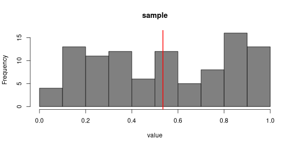

```r
n <- 100
x <- runif(n)
hist(x, xlab='value', main='sample', col=grey(0.5))
abline(v=mean(x), col='red', lwd=2)
```

## More samples

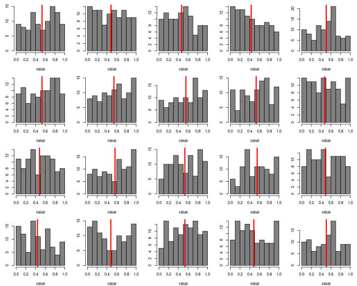

## Distribution of 1,000 sample means

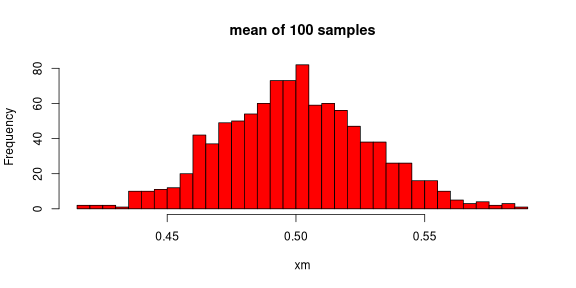

```r
xm <- replicate(1000, mean(runif(n)))
xh <- hist(xm, breaks=40, main=sprintf('mean of %d samples', n), col='red')
```

## Distribution of 1,000 sample means

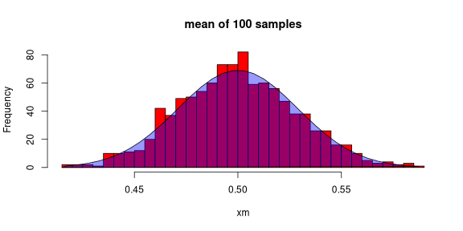

```r
plot(xh, main=sprintf('mean of %d samples', n), col='red')
xx <- xh$breaks
polygon(c(xx[-1] - diff(xx)/2, xx[1]),
        c(length(xm)* diff(pnorm(xx, mean=0.5, sd=1/sqrt(n*12))), 0),
        col=adjustcolor("blue", 0.4))
```

## Relationship to the $t$ distribution

If $Y$ and $Z_1, \ldots, Z_n$ are independent $\Normal(0, \sigma)$, and
$$\begin{equation}
X = \frac{Y}{ \sqrt{\frac{1}{n}\sum_{j=1}^n Z_j^2} }
\end{equation}$$
then
$$\begin{equation}
X \sim \StudentsT(n) .
\end{equation}$$

More usefully, *a sample mean divided by its standard error is$^*$ $t$ distributed.*

This is thanks to the Central Limit Theorem. ($^*$ usually, approximately)

## Stochastic tangent: other distributions

Simulate at least 1,000 random draws from each of these distributions, and make histograms:

- [`rnorm( )`](https://en.wikipedia.org/wiki/Normal_distribution)
- [`rexp( )`](https://en.wikipedia.org/wiki/Exponential_distribution)
- [`runif( )`](https://en.wikipedia.org/wiki/Uniform_distribution)
- [`rgamma( )`](https://en.wikipedia.org/wiki/Gamma_distribution)
- [`rpois( )`](https://en.wikipedia.org/wiki/Poisson_distribution)
- [`rgeom( )`](https://en.wikipedia.org/wiki/Geometric_distribution)
- [`rbinom( )`](https://en.wikipedia.org/wiki/Binomial_distribution)
- [`rnbinom( )`](https://en.wikipedia.org/wiki/Negative_binomial_distribution)
- [`rbeta( )`](https://en.wikipedia.org/wiki/Beta_distribution)

Things to notice: Which ones give you integers? positive numbers? numbers in a bounded region?